# Análise da Paisagem

Domínios de Natureza e Paisagens Tropicais  
Curso de Geografia

Luiz Diego Vidal Santos

## Visão Geral da Aula

### Tópicos

- 1 O conceito de Geossistema na tradição franco-brasileira
- 2 Bertrand (1971): taxonomia da paisagem
- 3 Monteiro (1976/2000): geossistemas no Brasil
- 4 Ab’Sáber (2003): domínios de natureza
- 5 Aplicação: paisagens do semiárido baiano
- 6 Exercício: identificação de domínios morfoclimáticos

**Objetivo da Aula**

Compreender as bases conceituais dos **geossistemas** e dos **domínios de natureza** como modelos de classificação e análise da paisagem brasileira, com ênfase na escola geográfica franco-brasileira.

# 1 - O GEOSSISTEMA: ORIGEM E EVOLUÇÃO

## De Sochava a Bertrand

O conceito de **geossistema** surgiu na escola soviética com Viktor Sochava (1963), que propôs tratar a paisagem como um sistema natural total â€” integrando litosfera, atmosfera, hidrosfera e biosfera.

Georges **Bertrand** (1971) reformulou o conceito para a tradição francesa, acrescentando a **ação antrópica** como componente estruturante do geossistema e propondo uma **taxonomia hierárquica** das unidades de paisagem.

> *“A paisagem não é a simples adição de elementos geográficos disparatados â€” é, em uma determinada porção do espaço, o resultado da combinação dinâmica, portanto instável, de elementos físicos, biológicos e antrópicos.”*

> â€” Bertrand (1971)

**Referência Fundamental**

**BERTRAND, G.** (1971). Paysage et géographie physique globale: esquisse méthodologique. *Rev. Géogr. Pyrénées SO*, **39**(3), 249â€“272.

Tradução brasileira em *RA’E GA*, v. 8, 2004.

## Taxonomia das Unidades de Paisagem

Bertrand propôs seis níveis taxonômicos hierárquicos para classificar as unidades de paisagem:

Taxonomia hierárquica de Bertrand (1971).

[output not shown]

**Note**

O **geossistema** é a unidade central de análise — escala compatível com bacias de 3ª–5ª ordem, onde a interação entre componentes é mais perceptível pela ação humana.

## Tripé do Geossistema

Bertrand concebeu o geossistema como a interação de três componentes:

[figure not shown]

Modelo do Geossistema segundo Bertrand (1971): tripé funcional.

A retroalimentação entre ação antrópica e potencial ecológico é o que diferencia o geossistema de um simples ecossistema â€” a **sociedade** é vista como componente interno, não externo.

# 2 - MONTEIRO: GEOSSISTEMAS NO BRASIL

## Carlos Augusto de Figueiredo Monteiro

Monteiro (1976, 2000) adaptou o conceito de geossistema à realidade brasileira, enfatizando:

- A **dinâmica climática** como motor de diferenciação paisagística no Brasil
- A necessidade de integrar dados **quantitativos** (climatológicos, hidrológicos) com análise **qualitativa** (uso da terra, percepção)
- O conceito de **derivações antropogênicas** â€” transformações impostas pela sociedade sobre o sistema natural

Monteiro introduziu o termo **geossistema urbano** para cidades brasileiras, ampliando o conceito para além das paisagens rurais/naturais.

**Referência**

**MONTEIRO, C.A.F.** (2000). *Geossistemas: a história de uma procura*. São Paulo: Contexto.

## Derivações Antropogênicas

Monteiro classificou as derivações antropogênicas em três tipos:

Tipos de derivações antropogênicas (Monteiro, 2000).

| Tipo de derivação | Descrição | Exemplo no Semiárido |
| --- | --- | --- |
| **Supressão** | Remoção de componentes do sistema | Desmatamento da caatinga para pecuária |
| **Inserção** | Introdução de componentes exógenos | Irrigação em áreas de sequeiro; espécies exóticas |
| **Alteração funcional** | Mudança nos fluxos e nos ritmos | Barramento de rios; urbanização de várzeas |

Essas derivações **acumulam-se no tempo**, criando trajetórias de degradação ou de recuperação que só são compreensíveis na perspectiva do geossistema.

# 3 - AB’SÁBER: DOMÍNIOS DE NATUREZA

## Os Domínios Morfoclimáticos

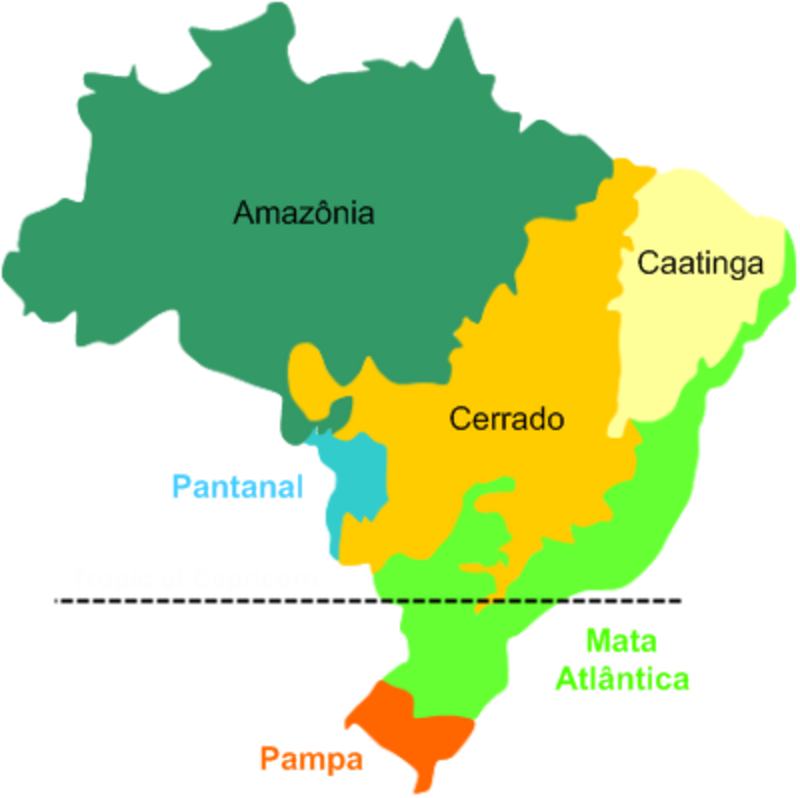

Aziz **Ab’Sáber** (2003) sintetizou décadas de pesquisa geomorfológica em uma classificação das grandes paisagens brasileiras em **seis domínios morfoclimáticos**:

1. **Amazônico** â€” terras baixas florestadas
2. **Cerrado** â€” chapadões tropicais com cerrados e florestas-galeria
3. **Mares de Morros** â€” relevo mamelonizado com Mata Atlântica
4. **Caatingas** â€” depressões interplanálticas semiáridas
5. **Araucárias** â€” planalto meridional com floresta mista
6. **Pradarias** â€” campos do sul com coxilhas

Entre os domínios situam-se as **faixas de transição** (*ecótonos macro-regionais*), onde as características se interpenetram.

**Referência Fundamental**

**AB’SÁBER, A.N.** (2003). *Os domínios de natureza no Brasil: potencialidades paisagísticas*. São Paulo: Ateliê Editorial.

## Três Níveis de Compreensão

Ab’Sáber propôs três **níveis taxonômicos** de leitura do meio ambiente:

Três níveis de compreensão do meio ambiente (Ab’Sáber, 2003).

| Nível | Acesso | O que revela |
| --- | --- | --- |
| 1º | **Compartimentação topográfica** | Formas de relevo regional (planaltos, depressões, planícies) |
| 2º | **Estrutura superficial da paisagem** | Solos, formações superficiais, mantos de intemperismo |
| 3º | **Fisiologia da paisagem** | Dinâmica climática, hidrológica e ecológica atual |

**Important**

O 3º nível — **fisiologia da paisagem** — corresponde à dinâmica dos processos atuais e é o mais suscetível às derivações antropogênicas de Monteiro.

## Domínio das Caatingas e o Semiárido Baiano

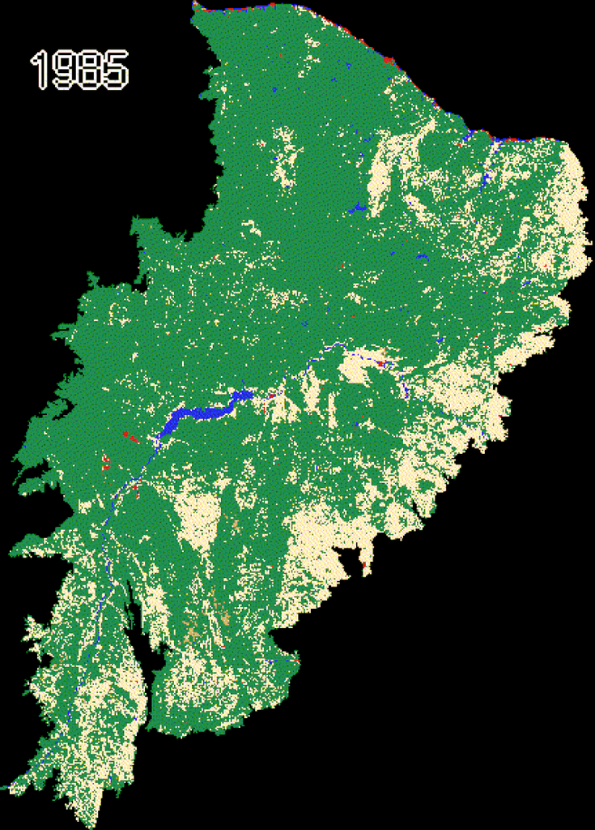

Vegetação da Caatinga no semiárido nordestino

Características do domínio:

- Depressões interplanálticas entre 200â€“500 m
- Clima BSh (Köppen): P < 800 mm/ano, chuvas concentradas em 3–5 meses
- Solos rasos (Neossolos Litólicos, Luvissolos)
- Vegetação caducifólia: arbustiva a arbórea
- **Paleoclimas**: evidências de períodos mais úmidos (enclaves de mata)

Aplicação para a Bahia:

- Bacia do Paraguaçu: transição Caatingaâ€“Mata Atlântica
- Chapada Diamantina: refúgio de altitude (campos rupestres)
- Raso da Catarina: caatinga hiperxerófila

### Exercício orientado

1. No Google Earth Engine ou QGIS, delimite em sua área de estudo os **compartimentos topográficos** (1º nível de Ab’Sáber)
2. Sobreponha mapas de solo e cobertura vegetal â†’ **estrutura superficial** (2º nível)
3. Analise séries NDVI (12 meses) â†’ **fisiologia** (3º nível)
4. Identifique qual **domínio** ou **faixa de transição** sua área representa

# 4 - SÍNTESE E CONEXÃ•ES

## Bertrand × Monteiro × Ab’Sáber

Comparação entre as três abordagens.

[output not shown]

As três abordagens são **complementares**: Ab’Sáber define o enquadramento macro, Bertrand fornece a taxonomia operacional e Monteiro insere a dinâmica temporal e antrópica.

## Conexão com a Disciplina

### Para cima (escalas maiores)

- Os domínios de Ab’Sáber contextualizam a **paisagem regional**
- Determinam o **potencial ecológico** de base

### Para baixo (escalas menores)

- Geossistema â†’ geofácies â†’ geótopo de Bertrand
- Conecta-se às **métricas FRAGSTATS** aplicadas em nível de mancha

### Para a prática

- **Diagnóstico integrado** (Aula 20) utiliza os 3 níveis de Ab’Sáber
- **Zoneamento geoambiental** (Aula 22) aplica a taxonomia de Bertrand
- **Trabalho de campo** (Aula 25) coleta dados para validar a fisiologia da paisagem

## Leituras Recomendadas

- **BERTRAND, G.** (1971). Paysage et géographie physique globale. *Rev. Géogr. Pyrénées SO*, 39(3), 249â€“272.
- **MONTEIRO, C.A.F.** (2000). *Geossistemas: a história de uma procura*. São Paulo: Contexto.
- **AB’SÁBER, A.N.** (2003). *Os domínios de natureza no Brasil*. São Paulo: Ateliê Editorial.
- **METZGER, J.P.** (2001). O que é ecologia de paisagens? *Biota Neotropica*, 1(1), 1â€“9.